# MSc in Molecular Biomedicine

Solutions to Assignments

Christoforos Nikolaou, Computational Genomics Group, BSRC ‘Alexander Fleming’

2020-12-04

## Assignment 3. Sequence Similarity and Clustering

### Introduction

The goal of this assignment will be to combine sequence similarity analysis with the clustering approaches we discussed last time.

Histone H4 is one of the most well-preserved proteins among eukaryotic organisms. In this assignment, you will have to assess **the degree of conservation** through **Needleman-Wunsch pair-wise alignment** in specific protein sequences derived from a broad group of eukaryotes.

The file you will find [here](https://www.dropbox.com/s/gz554anznooo91k/histone4.fa) contains the H4 protein sequences from the following organisms: (Homo sapiens: HUMAN, Mus musculus: MOUSE, Drosophila melanogaster: DROME, Arabidopsis thaliana: ARATH, Bos taurus: BOVIN, Caenorhabditis elegans: CAEEL : CHICK, Rattus norvegicus: RAT, Saccharomyces cerevisiae: YEAST, Xenopus laevis: XENLA)

### Stage 1

You are asked to:

1. Align all sequences with each other in pairs using the BLOSUM50 replacement table.
2. Indicate the alignment scores on a square table of $NXN$ dimensions

Auxiliary information: It is recommended that you use the the R::seqinr and BioConductor::Biostrings libraries. The installation of the former is done directly by R

```r
library("seqinr")
```

while for Biostrings you have to go through Bioconductor:

```r
library("Biostrings")
```

The reading of the sequences can be done with the $read.fasta()$ function of seqinr. Alignment will be performed with the Biostrings $pairwiseAlignment()$ function using the substitutionMatrix = “BLOSUM50” parameter.

Answer: Loading the sequences

```r
sequences<-read.fasta("histone4.fa")
```

```r
myseqs<-list()
for(i in 1:length(sequences)){
  myseqs[i]<-toupper(paste(sequences[[i]], collapse=""))
}
names(myseqs)<-names(sequences)
```

```r
alignMat<-matrix(0, nrow=length(myseqs), ncol=length(myseqs))
for(i in 1:length(myseqs)){
  for(j in 1:length(myseqs)){
    alignMat[i,j]<-pairwiseAlignment(myseqs[[i]], myseqs[[j]], substitutionMatrix="BLOSUM50", scoreOnly=T)
  }
}
```

```r
maxS<-max(alignMat)
alignMat<-1-(alignMat/maxS)
distMat<-as.dist(alignMat)
```

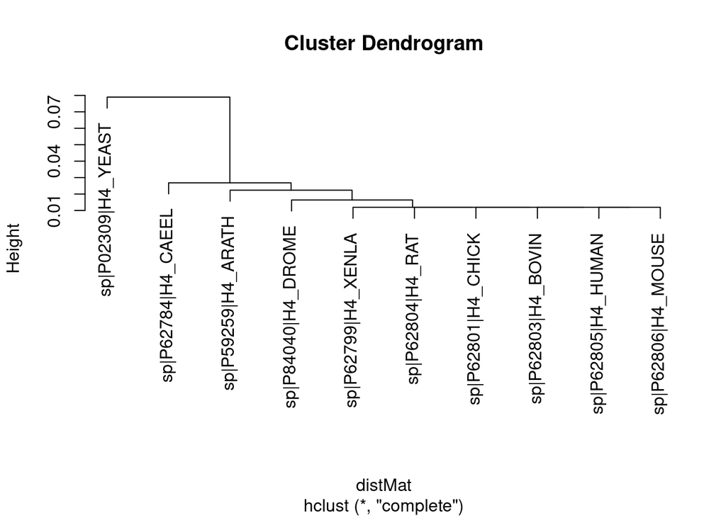

```r
hclSeq<-hclust(distMat, method = "complete")
plot(hclSeq, labels=names(myseqs))
```

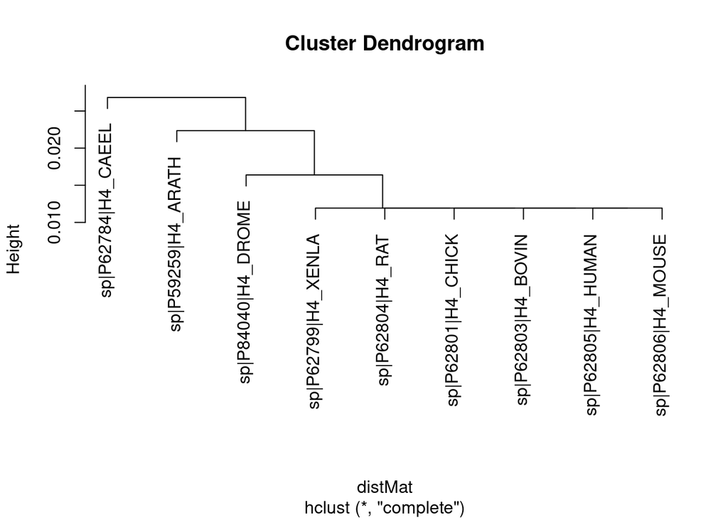

```r
myseqs<-myseqs[c(1:8,10)]
alignMat<-matrix(0, nrow=length(myseqs), ncol=length(myseqs))
for(i in 1:length(myseqs)){
  for(j in 1:length(myseqs)){
    alignMat[i,j]<-pairwiseAlignment(myseqs[[i]], myseqs[[j]], substitutionMatrix="BLOSUM50", scoreOnly=T)
  }
}
#
maxS<-max(alignMat)
alignMat<-1-(alignMat/maxS)
distMat<-as.dist(alignMat)
#
hclSeq<-hclust(distMat, method = "complete")
plot(hclSeq, labels=names(myseqs))
```